# Rの導入

SappoRo.R #5

kazutan

# 1 自己紹介

# 1.1 基本データ

- 比治山大学短期大学部
- @kazutan (Twitter, GitHub)
- http://kz-md.net/
- http://blog.kz-md.net/

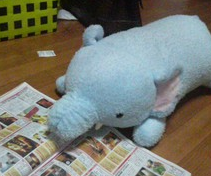

# 1.2 はい。

[figure not shown]

# 2 Rってなに?

# 2.1 統計解析を主とした環境

- オープンソース
  - コードが公開されています
- クロスプラットフォーム
  - Windows, Mac, LinuxでもOK
- (基本的に)CUI
  - **むしろ喜べ、コードを叩ける幸せを**
- 非常に活発!!
  - 書籍やWebなど情報たくさん!
  - 全国各地で勉強会が開催!

# 2.2 Rのいいところ

- 基本無料
  - 無課金(?)でもいけるけど、学習コストなどは(場合によっては)他より発生するかも
- 実装がはやい
  - 世界中のいろんな人が開発してるので、大抵の分析は誰かが実装してる
- 自分で実装できる
  - やりたい分析がみつからない→「なら自分で作ればいい」
- 大抵のことはRで完結
  - 本当にいろんなことができます

# 2.3 Rでできるいろんなこと

- Office suite系も
  - ドキュメント作成、集計表、グラフ、プレゼンスライドもOK
- 普通は専用ソフトが必要なことも
  - テキストマイニング、シミュレーション、Webスクレイピング、地図統計もOK
- 疲れた時の気分転換も
  - ライフゲーム、数独、マインスイーパも…

# 2.4 Rのちょっと残念なところ

- 速くは、ない
  - 処理にもよるけど最速ではない
- 英語が中心
  - 特にヘルプは全て英語
- 文字コードの闇
  - ｳﾜｧｧｧｧ

# 3 Rのインストール

# 3.1 Rのインストール

1. 「rproject」で検索
2. 左のCRANをクリック
3. 近いところ、もしくは0-Cloudをクリック
4. 「Download R for 」で自分のOSを選択
5. 以降それに順してインストール

[figure not shown]

# 3.2 Windowsへの導入

- **base**をダウンロードしてインストール
  - 日本語で可能です
  - よっぽどな理由がない限り32bit版は不要です
- **Rtools**もダウンロードしてインストール
  - 今後のことを考えて、入れておくことをおすすめします

# 3.3 MacOSへの導入

- Mavericks(10.9)以降
  - **R-3.2.2.pkg**をダウンロードしてインストール
- Snow Leopard(10.6)- Mountain Lion(10.8)
  - **R-3.2.1-snowleopard.pkg**をダウンロードしてインストール
- それより前
  - まじでかー
- Homebrewを使用する場合
  - おググりください

# 3.4 Linuxへの導入

大丈夫、君ならきっとできるさ。

# 4 RStudioのすすめ

# 4.1 Rの統合開発環境

- いろんなことが楽にできます
  - クロスプラットフォーム
  - 「プロジェクト」としてファイルを管理
  - 様々なファイルを編集可能
  - コード補完機能、データ読み込みなど
  - 出力もラクラク etc…

# 4.2 RStudioのインストール

- 安定版
  1. 「RStudio」で検索
  2. [RStudio.com](http://rstudio.com)へ移動
  3. 該当するOSを選択してダウンロード→インストール
- preview版
  1. https://www.rstudio.com/products/rstudio/download/preview/
  2. 該当するOSを選択してダウンロード→インストール

特に設定は(現時点で)考えなくていいです。さっそく起動させましょう

# 4.3 RStudioの画面

[figure not shown]

# 4.4 RStudioの各ペイン

- Source Editor
  - スクリプトやファイルなどを編集する場所
  - ソースコードを記述して保存・実行
  - 多くの人が一番利用するところ

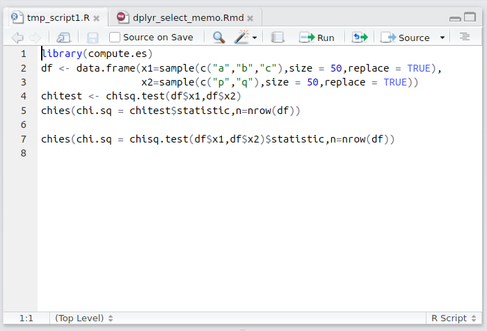

# 4.5 RStudioの各ペイン

- **Console**
  - Rと会話するところ
  - コマンドを記述して実行
  - ちょろっと作業するときはここ

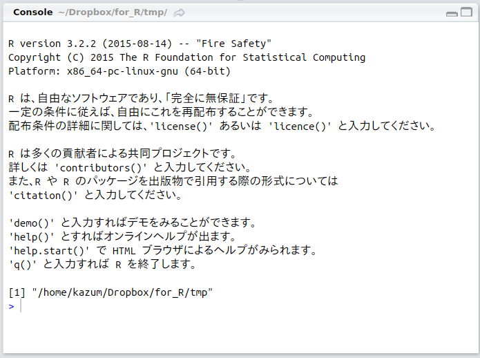

# 4.6 RStudioの各ペイン-右上

- **Environment, Historyなど**
  - Environment
    - 現在R上にあるオブジェクトなど
    - データとかを確認可能
  - History
    - コンソールで実行したコマンドの履歴

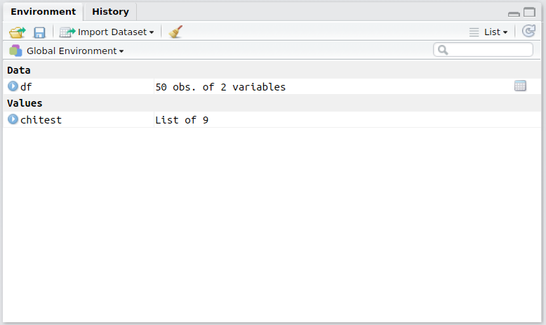

# 4.7 RStudioの各ペイン-右下

- **Files, Plot, Packages, Helpなど**
  - Filesでディレクトリ(フォルダ)にアクセス可能
  - Plotsに作図した図(グラフなど)が出力
  - Packagesでパッケージの管理
  - HelpでRのヘルプの検索・閲覧

[figure not shown]

# 4.8 詳細は省略…

- RStudioは「Rを便利にするもの」
  - それ以上でもそれ以下でもない
  - Rが使えないと意味がない!!
- 後で資料を紹介します

# 5 Rに触れてみよう

# 5.1 Hello, World

**コンソールの使い方**

以下が「コマンド?」状態:

```
>
```

試しに以下のコードをコンソールに入力してEnter

```r
1+1
```

ついでにこれもやってみよう

```r
41^2*271^2
```

# 5.2 関数を使おう

2の平方根を算出するには?

```r
sqrt(2)
```

```
## [1] 1.414214
```

- 関数とは「inputに対して決まった命令を実行してoutput」
- 上の場合、`2`という値を「その平方根を計算」して1.4142136を出す
  - この2を**引数(Arguments)**といいます
  - そして出てきた結果が**出力(Value)**です
- 関数は、**関数名(引数, 引数, 引数, …)**という感じで書きます

# 5.3 オブジェクトを使おう

Rは数値や文字などを**オブジェクト**という単位で管理

```r
# 今夜のbeerは500円です
beer <- 500
# beerの値段をRに聞いてみる
beer
```

```
## [1] 500
```

- この`beer`がオブジェクトです
  - 変数に感覚が近いです
  - いろんなものを入れて管理できます

# 5.4 オブジェクトに文字列を

```r
# 文字列を入れるときは""で挟む
drink <- "beer"
drink
```

```
## [1] "beer"
```

```r
# c()関数でまとめて入れることも可能
drink <- c("beer", "sake", "shochu")
drink
```

```
## [1] "beer"   "sake"   "shochu"
```

# 5.5 オブジェクトに数値を

```r
# 数値もまとめて可能
price <- c(500, 650, 450)
price
```

```
## [1] 500 650 450
```

```r
# こんなこともできます
seki <- 1:10
seki
```

```
##  [1]  1  2  3  4  5  6  7  8  9 10
```

# 5.6 オブジェクトを操作

```r
# 2つ目の要素にアクセス
price[2]
```

```
## [1] 650
```

```r
# 平均価格を算出しましょう
mean(price)
```

```
## [1] 533.3333
```

```r
# 税込価格を計算しましょう
price * 1.08
```

```
## [1] 540 702 486
```

# 5.7 data.frameとは

簡単に言えばスプレットシートみたいな形のデータ

```r
head(iris, 4)
```

```
##   Sepal.Length Sepal.Width Petal.Length Petal.Width Species
## 1          5.1         3.5          1.4         0.2  setosa
## 2          4.9         3.0          1.4         0.2  setosa
## 3          4.7         3.2          1.3         0.2  setosa
## 4          4.6         3.1          1.5         0.2  setosa
```

- 列が変数、行が1サンプル
- 列の長さは全て同じ(矩形)
- 扱い方は別途説明

# 6 パッケージ

# 6.1 パッケージって何?

- すごくざっくり言うと関数とかデータセットとかをまとめたもの
  - ツールセットみたいなイメージ
  - Rでできることを広げてくれます
- 現在CRANに登録されているパッケージ数はこれで調べられます:

```r
nrow(available.packages())
```

```
## [1] 7413
```

# 6.2 パッケージのインストール

例として`ggplot2`を使ってみます

```r
install.packages("ggplot2")
```

- これでインストールできます
- たまにエラーを返すことがあります
  - 多くはパッケージの依存関係が原因です
  - OSによって違ったり、そのマシンの環境によっても違ったり…
  - 難しかったら身近な詳しい人や「Rなんでも相談室」で聞きましょう

# 6.3 読み込みと実行

散布図を描きます

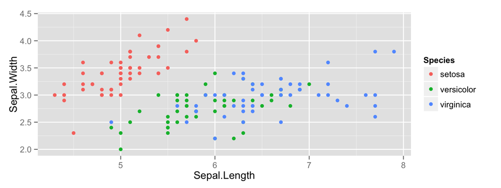

```r
# パッケージをRで読み込む
library("ggplot2")
# この中のggplot()関数を利用
ggplot(iris, aes(x=Sepal.Length, y=Sepal.Width, col=Species)) +
  geom_point()
```

# 7 Rをもっと使えるように

# 7.1 Webで資料を探す

- [Rjpwiki](http://www.okada.jp.org/RWiki/)
  - Rに関する日本のWiki。情報量膨大
- [seekR](http://seekr.jp/)
  - Rに特化した検索エンジン
- [山口大学教育学部心理学選修](http://psycho.edu.yamaguchi-u.ac.jp/)
  - [オンラインセミナー](http://psycho.edu.yamaguchi-u.ac.jp/?page_id=242)では動画でわかりやすく説明
    - RStudioについてもあります
  - [Rチュートリアルセミナーテキスト](http://psycho.edu.yamaguchi-u.ac.jp/?page_id=626)も公開

# 7.2 おすすめの書籍

### 7.2 [みんなのR](https://book.mynavi.jp/ec/products/detail/id=39763)

- Rをさわりはじめた方に最適!!
- 圧倒的…圧倒的ボリューム!!
- RStudioや新しいパッケージなど**モダン**な使い方が学べます
- これ1冊を写経できれば十分にOK

[figure not shown]

### 7.3 [改訂2版 R言語逆引きハンドブック](http://www.amazon.co.jp/dp/4863541473/)

- 初心者から中級者まで
- サンプルコード満載
- 困ったらこれを開く。  
  古事記にもそう書いてある

[figure not shown]

# 7.4 勉強会に出よう

**メリット**

- 知識が増える
- 刺激になる
- **つおいひとと知り合える**
- 仲間に出会える

**デメリット**

- 多くが不定期開催
- 地方だと頻度が少ない
- 内容が自分とあわないことも

# 7.5 SNSやチャットを活用

**Twitter**

- Rユーザーをフォローしてみよう
  - いろんな情報がガンガン垂れ流されてきます
- うまくいかないことをTLに流してみよう
  - 誰かがそっと教えてくれるかも?

**r-wakalang**

- “r-wakalang”もしくは“r-wakalang GitHub”で検索!
  - すごい人たちが質問を待ってます
  - 眺めているだけでも勉強になります

# 7.6 さいごに

> いいからコードを打つべし。

> — kazutan (@kazutan) [2015, 5月 21](https://twitter.com/kazutan/status/601399641712816129)

Enjoy!